# CCC

Install these packages (if needed):

```r
install.packages(c("Matrix", "igraph", "visNetwork"))
```

### The CCC data

We’ll use data from the Crowd Counting Consortium (CCC). The CCC covers U.S. protest events from 2017 to the present, with new updates each week. These data are collected using a combination of webcrawling, social media analysis, and crowd-sourced contributions. The time frame and geographic scope is narrower compared to sources like ACLED, but they also tend to catch more events and offer a higher level of detail about each one.

You can access the CCC data from their [github site](https://github.com/nonviolent-action-lab/crowd-counting-consortium). Note that they have two separate files: one for events from 2017-2020 and a separate one for events from 2021 to the present. We’ll work with the 2021-Present file today.

- [Website](https://ash.harvard.edu/programs/crowd-counting-consortium/)
- [Dataverse](https://dataverse.harvard.edu/dataverse/crowdcountingconsortium/) (note the data is stored in 3 separate waves)
- [Codebook for the current wave](https://dataverse.harvard.edu/file.xhtml?fileId=10808412&version=10.1)

We’ll start by reading the data in and taking a look at our results

```r
library(tidyverse)
url<-'https://dataverse.harvard.edu/api/access/datafile/12027896'
ccc<-read_csv(url)
```

## Basic Descriptives

Take a minute to explore the data and the codebook. Try:

- Using `valence` to get a count of right vs. left wing protest.
- Getting the number of total events.
- Getting a count of events by state.
- Identifying the proportion of protests that were online.
- Identify the most recent event covered.

```r
# your code here
```

## Unnesting

You’ll notice that many variables (`issue_tags` and `organizations` etc.) actually contain lists separated by semi-colons. This allows coders to record events involving multiple issues or groups, but for analysis this kind of coding raises some difficulties similar to the ones we encountered when using the Dynamics of Collective Action data.

```r
ccc|>
  select(issue_tags_summary)|>
  slice_head(n=5)
```

| issue_tags_summary |
| --- |
| banking and finance; economy; foreign affairs; healthcare; war and peace |
| war and peace; policing |
| foreign affairs; war and peace |
| foreign affairs; war and peace |
| economy; foreign affairs; war and peace |

To make these results use-able for an analysis, we’ll need to do some additional reshaping to these variables. I’ll use the `str_split` function to split a nested list into a vector of separate elements:

```r
str_split("banking and finance; economy; foreign affairs; healthcare; war and peace", pattern = "; ")
```

```
[[1]]
[1] "banking and finance" "economy"             "foreign affairs"
[4] "healthcare"          "war and peace"
```

Doing this to a data frame column will create a list-column where each row contains multiple values:

```r
ccc_issues<-ccc|>
  mutate(issue_tags_separated = str_split(issue_tags_summary, "; "))

ccc_issues$issue_tags_separated[1:3]
```

```
[[1]]
[1] "banking and finance" "economy"             "foreign affairs"
[4] "healthcare"          "war and peace"

[[2]]
[1] "war and peace" "policing"

[[3]]
[1] "foreign affairs" "war and peace"
```

I’ll use `unnest_longer` to create 1 new row for each element in this nested list. So, since the first event has five different issues listed, there will be five rows for that event. (I’ll also add a `event_id` tag so I can tell what tags go with the same events)

```r
ccc_issues_long<-ccc_issues|>
  mutate(event_id = row_number())|>
  unnest_longer(issue_tags_separated)

ccc_issues_long|>
  select(event_id, issue_tags_separated)|>
  slice_head(n =10)
```

| event_id | issue_tags_separated |
| --- | --- |
| 1 | banking and finance |
| 1 | economy |
| 1 | foreign affairs |
| 1 | healthcare |
| 1 | war and peace |
| 2 | war and peace |
| 2 | policing |
| 3 | foreign affairs |
| 3 | war and peace |
| 4 | foreign affairs |

Now I can use this result to do things like identify the most common issue tags across the data set:

```r
ccc_issues_long|>
  count(issue_tags_separated)|>
  arrange(-n)|>
  slice_head(n =10)
```

| issue_tags_separated | n |
| --- | --- |
| war and peace | 26504 |
| presidency | 13236 |
| foreign affairs | 7558 |
| democracy | 7073 |
| immigration | 5148 |
| healthcare | 4390 |
| economy | 3770 |
| civil rights | 3691 |
| labor and workers rights | 3542 |
| corruption | 3228 |

## Filtering on subjects

Another common goal is filtering the data based on some issue or topic. As with the ACLED data, we can filter the CCC data by matching different patterns in the text. Here’s a simple example of doing that to match events where “Students” were listed as participants:

```r
ccc|>
  filter(str_detect(participants, "[S|s]tudents"))|>
  count()
```

| n |
| --- |
| 767 |

These kinds of filters can get pretty elaborate. For instance, here’s a slightly modified example of a set of regular expressions that CCC researchers used to track and identify protests related to Israel/Palestine:

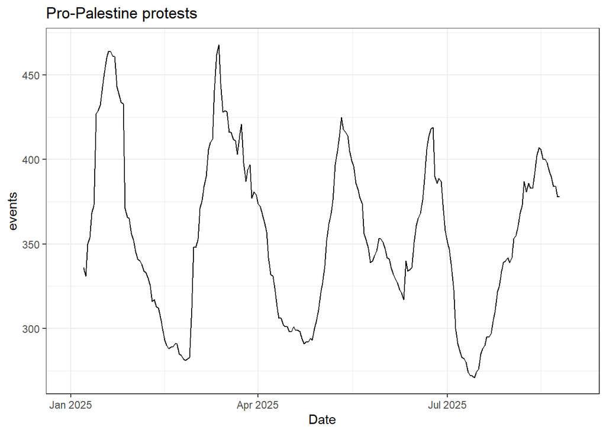

```r
regex_schools <- c("college(?! (?:st(reet)?|ave(nue)?|r(oa)?d|cir(cle)?|dr(ive)?\\b|blvd|heights|point|green|athletic))",
             "university(?! (?:st(reet)?|ave(nue)?|r(oa)?d|cir(cle)?|dr(ive)?\\b|blvd|heights|city|behavioral|hospital|plaza|lakes|office|irving))",
             "school(?! (?:st(reet)?\\b|ave(nue)?|r(oa)?d|cir(cle)?|dr(ive)?\\b|blvd|heights))",
             "\\bcooper union",
             "institute of technology",
             "\\bpoly(technic (state )?(?:institute|university))?",
             "auraria campus",
             "pentacrest",
             "(?:naval|air force|military) academy|west point(?! hwy)",
             "\\b(?:c|s)uny\\b",
             "\\buc\\b(?! theatre)")|>
  paste(collapse="|")
regex_pro_palestine <- c("for palestinian (?:liberation|rights)",
                         "free palestine(?! from hamas)",
                         "in solidarity with (?:palestin|gaza)",
                         "in remembrance of palestin",
                         "ceasefire in gaza",
                         "against apartheid in israel",
                         "(?:for ending|against) israel's occupation of palestin|genocide of palestin"
)|>
  paste(collapse="|")
regex_pro_israel <- c("against violent attack on israel",
                      "in (?:solidarity with|support of) israel",
                      "stand with israel")|>
  paste(collapse="|")

pal <- ccc |>
  filter(grepl(
    regex_pro_palestine,
    claims_summary,
    ignore.case = TRUE,
    perl = TRUE
  )) |>
  filter(!grepl("counter-protest", event_type)) |>
  filter(!grepl("in solidarity with Israel", claims_summary, ignore.case = TRUE)) |>
  mutate(
    schools = factor(ifelse(
      grepl(
        regex_schools,
        location,
        ignore.case = TRUE,
        perl = TRUE
      ),
      1,
      0
    ), labels = c("Not on campus", "On campus")),
    encampment = factor(ifelse(
      grepl("encamp", participant_measures, ignore.case = TRUE), 1, 0
    ), labels = c("no", "yes")),
    counterprotested = ifelse(!is.na(macroevent), 1, 0),
    side = 'pro-Palestine'
  )


pal|>
  count(date)|>
  complete(date = full_seq(date, period=1), fill=list(n=0))|>
  mutate(rolling_sum = zoo::rollsum(n, 14, na.pad=T))|>
  ggplot(aes(x=date, y=rolling_sum)) +
  geom_line() +
  theme_bw() +
  labs(x= "Date", y='events',
       title ='Pro-Palestine protests')+
  scale_x_date(date_labels = "%b %Y")
```

## Network analysis

We’ll set up an example of using this data to create a network visualization showing how frequently different groups protested together over the time period for this data set.

We’ll start by splitting the “organizations” column and recoding it to long format just like we did with the “issues” column. We’ll do a little extra pre-processing to ensure we capture slight variations in spelling and formatting:

```r
library(Matrix)
library(igraph)
library(visNetwork)
```

```r
orglist<-ccc|>
  mutate(orgs = str_split(organizations, "; "),
         rowid = row_number()

  )|>
  unnest_longer(orgs)|>
  mutate(orgs = str_squish(orgs)|>tolower())|>
  select(orgs, rowid)|>
  drop_na()|>
  group_by(orgs)|>
  mutate(count = n())|>
  ungroup()
```

Then, we’ll need to convert this data frame into an adjacency matrix. Essentially, this will be a matrix with columns and rows for each organization, along with a count of the number of times each group appeared together at the same event:

```r
tab<-table(orglist[c('rowid', 'orgs')])|>Matrix(sparse=TRUE) # making a sparse matrix
net_cmx<-crossprod(tab)
diag(net_cmx) <- 0  # setting the diagonals to zero
mat<-as.matrix(net_cmx)  # converting back to a regular matrix
```

Next, we’ll convert out matrix intoa a weighted graph

```r
g<-graph_from_adjacency_matrix(mat, mode='undirected', weighted=T)

table(degree(g))
```

```
   0    1    2    3    4    5    6    7    8    9   10   11   12   13   14   15
1673  865  629  450  279  270  186  128   77  131   65  128   73   28   60   55
  16   17   18   19   20   21   22   23   24   25   26   27   28   29   30   31
  16   31   24   28    7   10   73   26   24   21   26    6   57    6    3   28
  32   33   34   35   36   37   38   39   40   41   42   43   44   45   46   49
   8    4    4    5    3    2    3    2    3   33    6    4    2    3    1    2
  50   51   52   53   54   55   56   57   58   59   60   61   62   63   65   66
  21    1    3   33    4    1    2    3    1    2    1    2    4   18    1    1
  67   68   69   70   72   73   76   81   89   91   98  101  124  129  133  142
   2    1    1    2    1    1    2    1    1    1    1    1    1    1    1    1
 143  144  154  156  167  170  174  180  193  235  253  361  385
   7    2    1    1    1    1    2    2    1    1    1    1    1
```

We’ll use `delete_vertices` to remove some of the least connected nodes from the graph. This isn’t required, and it does mean we’re throwing away data, but laying out a network with lots of nodes will take a lot longer, so this step reduces some of the computational complexity”

```r
g <- delete_vertices(g, which(degree(g)  < 20))
# remove remaining nodes that are no longer connected to anything
g <- delete_vertices(g, which(degree(g)  < 1))
```

We’ll apply a layout algorithm to prepare the network for visualization. Different layout options from the igraph package will generate different versions of the same data, and the choice of algorithm is partly an aesthetic choice. `layout_with_fr` uses the Fruchterman–Reingold algorithm.

```r
layout <- layout_with_fr(g)
```

Finally, we’ll perform community detection to identify “clusters” of closely related nodes and then color code each one according to its community. This should help us identify related organizatons that tend to group together a lot.

```r
communities <- cluster_louvain(g)
num_communities <- length(communities)
palette <- rainbow(num_communities) # Or use other palettes like viridis, brewer.pal, etc.
V(g)$color <- palette[membership(communities)]
```

We’ll use `visIgraph` to generate an interactive version of our network. Just making the graph only requires the `visIgraph(g)` command, so the subsequent steps here are just adjusting some of the aesthetics.

```r
network<-visIgraph(g)|>
  visNodes(size=5,
           font = list(size=5),
    color = list(background = "lightblue",
                 border = "lightblue",
                 highlight = "yellow"),
    shadow = list(enabled = TRUE))|>
  visOptions(highlightNearest = TRUE, width=1920, height=720)|>
  visEdges(color = list(opacity = 0.3))|>
  visPhysics(
    solver = "barnesHut",
    barnesHut = list(
      springConstant = 0.04, # Adjust as needed
      avoidOverlap = 1     # Value between 0 and 1 (1 is max avoidance)
    )
  )

network
```

[interactive chart not shown]

```r
visSave(network, file='network.html')
```